# Credit Card Users Churn Prediction

## Problem Statement

### Business Context

The Thera bank recently saw a steep decline in the number of users of their credit card, credit cards are a good source of income for banks because of different kinds of fees charged by the banks like annual fees, balance transfer fees, and cash advance fees, late payment fees, foreign transaction fees, and others. Some fees are charged to every user irrespective of usage, while others are charged under specified circumstances.

Customers’ leaving credit cards services would lead bank to loss, so the bank wants to analyze the data of customers and identify the customers who will leave their credit card services and reason for same – so that bank could improve upon those areas

You as a Data scientist at Thera bank need to come up with a classification model that will help the bank improve its services so that customers do not renounce their credit cards

### Data Description

- CLIENTNUM: Client number. Unique identifier for the customer holding the account
- Attrition_Flag: Internal event (customer activity) variable - if the account is closed then "Attrited Customer" else "Existing Customer"
- Customer_Age: Age in Years
- Gender: Gender of the account holder
- Dependent_count: Number of dependents
- Education_Level: Educational Qualification of the account holder - Graduate, High School, Unknown, Uneducated, College(refers to college student), Post-Graduate, Doctorate
- Marital_Status: Marital Status of the account holder
- Income_Category: Annual Income Category of the account holder
- Card_Category: Type of Card
- Months_on_book: Period of relationship with the bank (in months)
- Total_Relationship_Count: Total no. of products held by the customer
- Months_Inactive_12_mon: No. of months inactive in the last 12 months
- Contacts_Count_12_mon: No. of Contacts in the last 12 months
- Credit_Limit: Credit Limit on the Credit Card
- Total_Revolving_Bal: Total Revolving Balance on the Credit Card
- Avg_Open_To_Buy: Open to Buy Credit Line (Average of last 12 months)
- Total_Amt_Chng_Q4_Q1: Change in Transaction Amount (Q4 over Q1)
- Total_Trans_Amt: Total Transaction Amount (Last 12 months)
- Total_Trans_Ct: Total Transaction Count (Last 12 months)
- Total_Ct_Chng_Q4_Q1: Change in Transaction Count (Q4 over Q1)
- Avg_Utilization_Ratio: Average Card Utilization Ratio

#### What Is a Revolving Balance?

- If we don't pay the balance of the revolving credit account in full every month, the unpaid portion carries over to the next month. That's called a revolving balance

##### What is the Average Open to buy?

- 'Open to Buy' means the amount left on your credit card to use. Now, this column represents the average of this value for the last 12 months.

##### What is the Average utilization Ratio?

- The Avg_Utilization_Ratio represents how much of the available credit the customer spent. This is useful for calculating credit scores.

##### Relation b/w Avg_Open_To_Buy, Credit_Limit and Avg_Utilization_Ratio:

- ( Avg_Open_To_Buy / Credit_Limit ) + Avg_Utilization_Ratio = 1

### **Please read the instructions carefully before starting the project.**

This is a commented Jupyter IPython Notebook file in which all the instructions and tasks to be performed are mentioned.

- Blanks '**___**' are provided in the notebook that needs to be filled with an appropriate code to get the correct result. With every '**___**' blank, there is a comment that briefly describes what needs to be filled in the blank space.
- Identify the task to be performed correctly, and only then proceed to write the required code.
- Fill the code wherever asked by the commented lines like "# write your code here" or "# complete the code". Running incomplete code may throw error.
- Please run the codes in a sequential manner from the beginning to avoid any unnecessary errors.
- Add the results/observations (wherever mentioned) derived from the analysis in the presentation and submit the same.

## Importing necessary libraries

```python
# uncomment and run the next line in case Jupyter Notebook IDE is being used

# To supress warnings
import warnings

warnings.filterwarnings("ignore")

# !pip install imblearn
# scikit-learn 1.2.2 to fix build issues
#!pip uninstall scikit-learn --yes
#!pip uninstall imblearn --yes
!pip install scikit-learn==1.2.2
!pip install imblearn
```

```python
# import libraries for data manipulation
import numpy as np
import pandas as pd

# import libraries for data visualization
import matplotlib.pyplot as plt
import seaborn as sns

# import libraries to build model for prediction
from sklearn.linear_model import LogisticRegression
from sklearn.tree import DecisionTreeClassifier
from sklearn import tree

# import libraries to tune different models
# To do hyperparameter tuning
from sklearn.model_selection import GridSearchCV, RandomizedSearchCV
from sklearn.model_selection import train_test_split, StratifiedKFold, cross_val_score

# import libraries to get diferent metric scores
from sklearn import metrics
from sklearn.metrics import (
    f1_score,
    accuracy_score,
    recall_score,
    precision_score,
    confusion_matrix,
    roc_auc_score,
    #plot_confusion_matrix,# plot_confusion_matrix has been replaced with ConfusionMatrixDisplay
    ConfusionMatrixDisplay,
    precision_recall_curve,
    roc_curve,
    make_scorer,
)

# To be used for data scaling and one hot encoding
from sklearn.preprocessing import StandardScaler, MinMaxScaler, OneHotEncoder

# To impute missing values
from sklearn.impute import SimpleImputer

# To help with model building
from sklearn.tree import DecisionTreeClassifier
from sklearn.ensemble import (
    AdaBoostClassifier,
    GradientBoostingClassifier,
    RandomForestClassifier,
    BaggingClassifier,
)
# from xgboost import XGBClassifier

# To oversample and undersample data
from imblearn.over_sampling import SMOTE
from imblearn.under_sampling import RandomUnderSampler

# To define maximum number of columns to be displayed in a dataframe
pd.set_option("display.max_columns", None)

# To supress scientific notations for a dataframe
pd.set_option("display.float_format", lambda x: "%.3f" % x)

# To suppress scientific notations
pd.set_option("display.float_format", lambda x: "%.3f" % x)

# To supress warnings
import warnings

warnings.filterwarnings("ignore")
```

```python
# defining the filename and feature names in UPPERCASE for readability.
# BankChurners csv file
CSV_FILE='BankChurners.csv'

# features
CLIENTNUM = 'CLIENTNUM'
ATTRITION_FLAG = 'Attrition_Flag'
CUSTOMER_AGE = 'Customer_Age'
GENDER = 'Gender'
DEPENDENT_COUNT = 'Dependent_count'
EDUCATION_LEVEL = 'Education_Level'
MARITAL_STATUS = 'Marital_Status'
INCOME_CATEGORY = 'Income_Category'
CARD_CATEGORY = 'Card_Category'
MONTHS_ON_BOOK = 'Months_on_book'
TOTAL_RELATIONSHIP_COUNT = 'Total_Relationship_Count'
MONTHS_INACTIVE_12_MON = 'Months_Inactive_12_mon'
CONTACTS_COUNT_12_MON = 'Contacts_Count_12_mon'
CREDIT_LIMIT = 'Credit_Limit'
TOTAL_REVOLVING_BAL = 'Total_Revolving_Bal'
AVG_OPEN_TO_BUY = 'Avg_Open_To_Buy'
TOTAL_AMT_CHNG_Q4_Q1 = 'Total_Amt_Chng_Q4_Q1'
TOTAL_TRANS_AMT = 'Total_Trans_Amt'
TOTAL_TRANS_CT = 'Total_Trans_Ct'
TOTAL_CT_CHNG_Q4_Q1 = 'Total_Ct_Chng_Q4_Q1'
AVG_UTILIZATION_RATIO = 'Avg_Utilization_Ratio'
```

## Loading the dataset

```python
# uncomment and run the following lines for Google Colab
# from google.colab import drive
# drive.mount('/content/drive')
```

```python
# read the csv file from current folder
df_cc_churn = pd.read_csv(CSV_FILE)
```

```python
# taking a copy just in case
df_raw=df_cc_churn.copy()
```

## Data Overview

- Observations
- Sanity checks

### 1. Shape of the data

```python
# shape function returns the rows and columns as tuple.
# for better formatting reading the rows and columns separately
rows=df_raw.shape[0]
columns=df_raw.shape[1]
print(rows, 'rows and', columns,'columns are present in the data.')
```

```
10127 rows and 21 columns are present in the data.
```

### 2. Head - First 5 rows of the data

```python
# head function to show the first 5 rows of the data
df_raw.head(5)
```

|  | CLIENTNUM | Attrition_Flag | Customer_Age | Gender | Dependent_count | Education_Level | Marital_Status | Income_Category | Card_Category | Months_on_book | Total_Relationship_Count | Months_Inactive_12_mon | Contacts_Count_12_mon | Credit_Limit | Total_Revolving_Bal | Avg_Open_To_Buy | Total_Amt_Chng_Q4_Q1 | Total_Trans_Amt | Total_Trans_Ct | Total_Ct_Chng_Q4_Q1 | Avg_Utilization_Ratio |
| --- | --- | --- | --- | --- | --- | --- | --- | --- | --- | --- | --- | --- | --- | --- | --- | --- | --- | --- | --- | --- | --- |
| 0 | 768805383 | Existing Customer | 45 | M | 3 | High School | Married | $60K - $80K | Blue | 39 | 5 | 1 | 3 | 12691.000 | 777 | 11914.000 | 1.335 | 1144 | 42 | 1.625 | 0.061 |
| 1 | 818770008 | Existing Customer | 49 | F | 5 | Graduate | Single | Less than $40K | Blue | 44 | 6 | 1 | 2 | 8256.000 | 864 | 7392.000 | 1.541 | 1291 | 33 | 3.714 | 0.105 |
| 2 | 713982108 | Existing Customer | 51 | M | 3 | Graduate | Married | $80K - $120K | Blue | 36 | 4 | 1 | 0 | 3418.000 | 0 | 3418.000 | 2.594 | 1887 | 20 | 2.333 | 0.000 |
| 3 | 769911858 | Existing Customer | 40 | F | 4 | High School | NaN | Less than $40K | Blue | 34 | 3 | 4 | 1 | 3313.000 | 2517 | 796.000 | 1.405 | 1171 | 20 | 2.333 | 0.760 |
| 4 | 709106358 | Existing Customer | 40 | M | 3 | Uneducated | Married | $60K - $80K | Blue | 21 | 5 | 1 | 0 | 4716.000 | 0 | 4716.000 | 2.175 | 816 | 28 | 2.500 | 0.000 |

### 3. Tail - Last 5 rows of the data

```python
# tail function to show the last 5 rows of the data
df_raw.tail(5)
```

|  | CLIENTNUM | Attrition_Flag | Customer_Age | Gender | Dependent_count | Education_Level | Marital_Status | Income_Category | Card_Category | Months_on_book | Total_Relationship_Count | Months_Inactive_12_mon | Contacts_Count_12_mon | Credit_Limit | Total_Revolving_Bal | Avg_Open_To_Buy | Total_Amt_Chng_Q4_Q1 | Total_Trans_Amt | Total_Trans_Ct | Total_Ct_Chng_Q4_Q1 | Avg_Utilization_Ratio |
| --- | --- | --- | --- | --- | --- | --- | --- | --- | --- | --- | --- | --- | --- | --- | --- | --- | --- | --- | --- | --- | --- |
| 10122 | 772366833 | Existing Customer | 50 | M | 2 | Graduate | Single | $40K - $60K | Blue | 40 | 3 | 2 | 3 | 4003.000 | 1851 | 2152.000 | 0.703 | 15476 | 117 | 0.857 | 0.462 |
| 10123 | 710638233 | Attrited Customer | 41 | M | 2 | NaN | Divorced | $40K - $60K | Blue | 25 | 4 | 2 | 3 | 4277.000 | 2186 | 2091.000 | 0.804 | 8764 | 69 | 0.683 | 0.511 |
| 10124 | 716506083 | Attrited Customer | 44 | F | 1 | High School | Married | Less than $40K | Blue | 36 | 5 | 3 | 4 | 5409.000 | 0 | 5409.000 | 0.819 | 10291 | 60 | 0.818 | 0.000 |
| 10125 | 717406983 | Attrited Customer | 30 | M | 2 | Graduate | NaN | $40K - $60K | Blue | 36 | 4 | 3 | 3 | 5281.000 | 0 | 5281.000 | 0.535 | 8395 | 62 | 0.722 | 0.000 |
| 10126 | 714337233 | Attrited Customer | 43 | F | 2 | Graduate | Married | Less than $40K | Silver | 25 | 6 | 2 | 4 | 10388.000 | 1961 | 8427.000 | 0.703 | 10294 | 61 | 0.649 | 0.189 |

### 4. data types of the columns

```python
# info function to show the data types of the columns
df_raw.info()
```

```
<class 'pandas.core.frame.DataFrame'>
RangeIndex: 10127 entries, 0 to 10126
Data columns (total 21 columns):
 #   Column                    Non-Null Count  Dtype
---  ------                    --------------  -----
 0   CLIENTNUM                 10127 non-null  int64
 1   Attrition_Flag            10127 non-null  object
 2   Customer_Age              10127 non-null  int64
 3   Gender                    10127 non-null  object
 4   Dependent_count           10127 non-null  int64
 5   Education_Level           8608 non-null   object
 6   Marital_Status            9378 non-null   object
 7   Income_Category           10127 non-null  object
 8   Card_Category             10127 non-null  object
 9   Months_on_book            10127 non-null  int64
 10  Total_Relationship_Count  10127 non-null  int64
 11  Months_Inactive_12_mon    10127 non-null  int64
 12  Contacts_Count_12_mon     10127 non-null  int64
 13  Credit_Limit              10127 non-null  float64
 14  Total_Revolving_Bal       10127 non-null  int64
 15  Avg_Open_To_Buy           10127 non-null  float64
 16  Total_Amt_Chng_Q4_Q1      10127 non-null  float64
 17  Total_Trans_Amt           10127 non-null  int64
 18  Total_Trans_Ct            10127 non-null  int64
 19  Total_Ct_Chng_Q4_Q1       10127 non-null  float64
 20  Avg_Utilization_Ratio     10127 non-null  float64
dtypes: float64(5), int64(10), object(6)
memory usage: 1.6+ MB
```

### Observations

```
A. There are attributes of 3 different types such as int64(10), object(6) and float64(5) in the data.
    a. The following 10 features/columns of the data type int64.
        1. CLIENTNUM
        2. Customer_Age
        3. Dependent_count
        4. Months_on_book
        5. Total_Relationship_Count
        6. Months_Inactive_12_mon
        7. Contacts_Count_12_mon
        8. Total_Revolving_Bal
        9. Total_Trans_Amt
        10. Total_Trans_Ct
    b. The following 6 features/columns of the data type object.
        1. Attrition_Flag
        2. Gender
        3. Education_Level
        4. Marital_Status
        5. Income_Category
        6. Card_Category
    c. The following 5 features/columns of the data type float64.
        1. Credit_Limit
        2. Avg_Open_To_Buy
        3. Total_Amt_Chng_Q4_Q1
        4. Total_Ct_Chng_Q4_Q1
        5. Avg_Utilization_Ratio
B. Memory Usage is 1.6+ MB.
```

### 5. Statistical summary of the data

```python
# describe function to show statistical summary of the data.
# For readability used Transpose(.T)
df_raw.describe().T
```

|  | count | mean | std | min | 25% | 50% | 75% | max |
| --- | --- | --- | --- | --- | --- | --- | --- | --- |
| CLIENTNUM | 10127.000 | 739177606.334 | 36903783.450 | 708082083.000 | 713036770.500 | 717926358.000 | 773143533.000 | 828343083.000 |
| Customer_Age | 10127.000 | 46.326 | 8.017 | 26.000 | 41.000 | 46.000 | 52.000 | 73.000 |
| Dependent_count | 10127.000 | 2.346 | 1.299 | 0.000 | 1.000 | 2.000 | 3.000 | 5.000 |
| Months_on_book | 10127.000 | 35.928 | 7.986 | 13.000 | 31.000 | 36.000 | 40.000 | 56.000 |
| Total_Relationship_Count | 10127.000 | 3.813 | 1.554 | 1.000 | 3.000 | 4.000 | 5.000 | 6.000 |
| Months_Inactive_12_mon | 10127.000 | 2.341 | 1.011 | 0.000 | 2.000 | 2.000 | 3.000 | 6.000 |
| Contacts_Count_12_mon | 10127.000 | 2.455 | 1.106 | 0.000 | 2.000 | 2.000 | 3.000 | 6.000 |
| Credit_Limit | 10127.000 | 8631.954 | 9088.777 | 1438.300 | 2555.000 | 4549.000 | 11067.500 | 34516.000 |
| Total_Revolving_Bal | 10127.000 | 1162.814 | 814.987 | 0.000 | 359.000 | 1276.000 | 1784.000 | 2517.000 |
| Avg_Open_To_Buy | 10127.000 | 7469.140 | 9090.685 | 3.000 | 1324.500 | 3474.000 | 9859.000 | 34516.000 |
| Total_Amt_Chng_Q4_Q1 | 10127.000 | 0.760 | 0.219 | 0.000 | 0.631 | 0.736 | 0.859 | 3.397 |
| Total_Trans_Amt | 10127.000 | 4404.086 | 3397.129 | 510.000 | 2155.500 | 3899.000 | 4741.000 | 18484.000 |
| Total_Trans_Ct | 10127.000 | 64.859 | 23.473 | 10.000 | 45.000 | 67.000 | 81.000 | 139.000 |
| Total_Ct_Chng_Q4_Q1 | 10127.000 | 0.712 | 0.238 | 0.000 | 0.582 | 0.702 | 0.818 | 3.714 |
| Avg_Utilization_Ratio | 10127.000 | 0.275 | 0.276 | 0.000 | 0.023 | 0.176 | 0.503 | 0.999 |

### Observations

#### 5.A DataType (int64) summary

```python
# summary of all the columns/features of type int64.
df_raw.describe(include=['int64'])
```

|  | CLIENTNUM | Customer_Age | Dependent_count | Months_on_book | Total_Relationship_Count | Months_Inactive_12_mon | Contacts_Count_12_mon | Total_Revolving_Bal | Total_Trans_Amt | Total_Trans_Ct |
| --- | --- | --- | --- | --- | --- | --- | --- | --- | --- | --- |
| count | 10127.000 | 10127.000 | 10127.000 | 10127.000 | 10127.000 | 10127.000 | 10127.000 | 10127.000 | 10127.000 | 10127.000 |
| mean | 739177606.334 | 46.326 | 2.346 | 35.928 | 3.813 | 2.341 | 2.455 | 1162.814 | 4404.086 | 64.859 |
| std | 36903783.450 | 8.017 | 1.299 | 7.986 | 1.554 | 1.011 | 1.106 | 814.987 | 3397.129 | 23.473 |
| min | 708082083.000 | 26.000 | 0.000 | 13.000 | 1.000 | 0.000 | 0.000 | 0.000 | 510.000 | 10.000 |
| 25% | 713036770.500 | 41.000 | 1.000 | 31.000 | 3.000 | 2.000 | 2.000 | 359.000 | 2155.500 | 45.000 |
| 50% | 717926358.000 | 46.000 | 2.000 | 36.000 | 4.000 | 2.000 | 2.000 | 1276.000 | 3899.000 | 67.000 |
| 75% | 773143533.000 | 52.000 | 3.000 | 40.000 | 5.000 | 3.000 | 3.000 | 1784.000 | 4741.000 | 81.000 |
| max | 828343083.000 | 73.000 | 5.000 | 56.000 | 6.000 | 6.000 | 6.000 | 2517.000 | 18484.000 | 139.000 |

#### 5.B DataType (float64) summary

```python
# statistical summary of the columns/features of type float64.
df_raw.describe(include=['float64'])
```

|  | Credit_Limit | Avg_Open_To_Buy | Total_Amt_Chng_Q4_Q1 | Total_Ct_Chng_Q4_Q1 | Avg_Utilization_Ratio |
| --- | --- | --- | --- | --- | --- |
| count | 10127.000 | 10127.000 | 10127.000 | 10127.000 | 10127.000 |
| mean | 8631.954 | 7469.140 | 0.760 | 0.712 | 0.275 |
| std | 9088.777 | 9090.685 | 0.219 | 0.238 | 0.276 |
| min | 1438.300 | 3.000 | 0.000 | 0.000 | 0.000 |
| 25% | 2555.000 | 1324.500 | 0.631 | 0.582 | 0.023 |
| 50% | 4549.000 | 3474.000 | 0.736 | 0.702 | 0.176 |
| 75% | 11067.500 | 9859.000 | 0.859 | 0.818 | 0.503 |
| max | 34516.000 | 34516.000 | 3.397 | 3.714 | 0.999 |

#### 5.C datatype (object) summary

```python
# statistical summary of all the featues/columns of object type.
df_raw.describe(include=['object'])
```

|  | Attrition_Flag | Gender | Education_Level | Marital_Status | Income_Category | Card_Category |
| --- | --- | --- | --- | --- | --- | --- |
| count | 10127 | 10127 | 8608 | 9378 | 10127 | 10127 |
| unique | 2 | 2 | 6 | 3 | 6 | 4 |
| top | Existing Customer | F | Graduate | Married | Less than $40K | Blue |
| freq | 8500 | 5358 | 3128 | 4687 | 3561 | 9436 |

## Data Preprocessing

### 1. Checking for missing values

```python
# checking for missing values if any
df_raw.isnull().sum()
```

```
CLIENTNUM                      0
Attrition_Flag                 0
Customer_Age                   0
Gender                         0
Dependent_count                0
Education_Level             1519
Marital_Status               749
Income_Category                0
Card_Category                  0
Months_on_book                 0
Total_Relationship_Count       0
Months_Inactive_12_mon         0
Contacts_Count_12_mon          0
Credit_Limit                   0
Total_Revolving_Bal            0
Avg_Open_To_Buy                0
Total_Amt_Chng_Q4_Q1           0
Total_Trans_Amt                0
Total_Trans_Ct                 0
Total_Ct_Chng_Q4_Q1            0
Avg_Utilization_Ratio          0
dtype: int64
```

### Observation

```
There are missing values in the following columns/features.
    1. Education_Level has 1519 missing values.
    2. Marital_Status has 749 missing values.
```

```python
# checking the number of unique values in each column
df_raw.nunique()
```

```
CLIENTNUM                   10127
Attrition_Flag                  2
Customer_Age                   45
Gender                          2
Dependent_count                 6
Education_Level                 6
Marital_Status                  3
Income_Category                 6
Card_Category                   4
Months_on_book                 44
Total_Relationship_Count        6
Months_Inactive_12_mon          7
Contacts_Count_12_mon           7
Credit_Limit                 6205
Total_Revolving_Bal          1974
Avg_Open_To_Buy              6813
Total_Amt_Chng_Q4_Q1         1158
Total_Trans_Amt              5033
Total_Trans_Ct                126
Total_Ct_Chng_Q4_Q1           830
Avg_Utilization_Ratio         964
dtype: int64
```

### 2. Checking for duplicates if any

```python
# checking for duplicate rows
df_raw[df_raw.duplicated()]
```

|  | CLIENTNUM | Attrition_Flag | Customer_Age | Gender | Dependent_count | Education_Level | Marital_Status | Income_Category | Card_Category | Months_on_book | Total_Relationship_Count | Months_Inactive_12_mon | Contacts_Count_12_mon | Credit_Limit | Total_Revolving_Bal | Avg_Open_To_Buy | Total_Amt_Chng_Q4_Q1 | Total_Trans_Amt | Total_Trans_Ct | Total_Ct_Chng_Q4_Q1 | Avg_Utilization_Ratio |
| --- | --- | --- | --- | --- | --- | --- | --- | --- | --- | --- | --- | --- | --- | --- | --- | --- | --- | --- | --- | --- | --- |

```python
# checking for duplicate values
df_raw.duplicated()
```

```
0        False
1        False
2        False
3        False
4        False
         ...
10122    False
10123    False
10124    False
10125    False
10126    False
Length: 10127, dtype: bool
```

### 3. Checking unique values of all the features/columns of type "object".

```python
for i in df_raw.describe(include=["object"]).columns:
    print("Unique values in", i, "are :")
    print(df_raw[i].value_counts())
    print("*" * 50)
```

```
Unique values in Attrition_Flag are :
Existing Customer    8500
Attrited Customer    1627
Name: Attrition_Flag, dtype: int64
Unique values in Gender are :
F    5358
M    4769
Name: Gender, dtype: int64
Unique values in Education_Level are :
Graduate         3128
High School      2013
Uneducated       1487
College          1013
Post-Graduate     516
Doctorate         451
Name: Education_Level, dtype: int64
Unique values in Marital_Status are :
Married     4687
Single      3943
Divorced     748
Name: Marital_Status, dtype: int64
Unique values in Income_Category are :
Less than $40K    3561
$40K - $60K       1790
$80K - $120K      1535
$60K - $80K       1402
abc               1112
$120K +            727
Name: Income_Category, dtype: int64
Unique values in Card_Category are :
Blue        9436
Silver       555
Gold         116
Platinum      20
Name: Card_Category, dtype: int64
```

### 4. Drop the insignificant column "CLIENTNUM"

```python
# CLIENTNUM is not a significant column/less weighted parameter. Hence dropping it.
# drop function to drop the column 'CLIENTNUM'. setting the axis = 1.
df=df_raw.drop('CLIENTNUM', axis=1)
```

```python
# check the info of the data after dropping the column 'CLIENTNUM' to confirm the drop is successful.
df.info()
```

```
<class 'pandas.core.frame.DataFrame'>
RangeIndex: 10127 entries, 0 to 10126
Data columns (total 20 columns):
 #   Column                    Non-Null Count  Dtype
---  ------                    --------------  -----
 0   Attrition_Flag            10127 non-null  object
 1   Customer_Age              10127 non-null  int64
 2   Gender                    10127 non-null  object
 3   Dependent_count           10127 non-null  int64
 4   Education_Level           8608 non-null   object
 5   Marital_Status            9378 non-null   object
 6   Income_Category           10127 non-null  object
 7   Card_Category             10127 non-null  object
 8   Months_on_book            10127 non-null  int64
 9   Total_Relationship_Count  10127 non-null  int64
 10  Months_Inactive_12_mon    10127 non-null  int64
 11  Contacts_Count_12_mon     10127 non-null  int64
 12  Credit_Limit              10127 non-null  float64
 13  Total_Revolving_Bal       10127 non-null  int64
 14  Avg_Open_To_Buy           10127 non-null  float64
 15  Total_Amt_Chng_Q4_Q1      10127 non-null  float64
 16  Total_Trans_Amt           10127 non-null  int64
 17  Total_Trans_Ct            10127 non-null  int64
 18  Total_Ct_Chng_Q4_Q1       10127 non-null  float64
 19  Avg_Utilization_Ratio     10127 non-null  float64
dtypes: float64(5), int64(9), object(6)
memory usage: 1.5+ MB
```

```python
# Function to Calculate the Coefficient of Variation
def coef_var(col):
    return round(df[col].std()/df[col].mean() * 100, 3)

columns = ['Customer_Age','Dependent_count','Months_on_book','Total_Relationship_Count','Months_Inactive_12_mon',
          'Contacts_Count_12_mon','Credit_Limit','Total_Revolving_Bal','Avg_Open_To_Buy','Total_Amt_Chng_Q4_Q1',
           'Total_Trans_Amt','Total_Trans_Ct','Total_Ct_Chng_Q4_Q1','Avg_Utilization_Ratio']
for colname in columns:
    cf = coef_var(colname)
    print('The coefficient of variation for', colname, 'is :' , cf, '%')
```

```
The coefficient of variation for Customer_Age is : 17.305 %
The coefficient of variation for Dependent_count is : 55.362 %
The coefficient of variation for Months_on_book is : 22.229 %
The coefficient of variation for Total_Relationship_Count is : 40.77 %
The coefficient of variation for Months_Inactive_12_mon is : 43.167 %
The coefficient of variation for Contacts_Count_12_mon is : 45.054 %
The coefficient of variation for Credit_Limit is : 105.292 %
The coefficient of variation for Total_Revolving_Bal is : 70.088 %
The coefficient of variation for Avg_Open_To_Buy is : 121.71 %
The coefficient of variation for Total_Amt_Chng_Q4_Q1 is : 28.845 %
The coefficient of variation for Total_Trans_Amt is : 77.136 %
The coefficient of variation for Total_Trans_Ct is : 36.19 %
The coefficient of variation for Total_Ct_Chng_Q4_Q1 is : 33.429 %
The coefficient of variation for Avg_Utilization_Ratio is : 100.29 %
```

#### Observations

1. The coefficient of variation tells us that the spread out values are in relation to the mean.
2. Most of our numerical variables have well spread out datapoints.
3. The following features have coefficient of variations over 100%.

   ```
    A. 'Credit_Limit',
    B. 'Avg_Open_To_Buy',
    C. 'Avg_Utilization_Ratio'
    It suggests that the existence of outliers within these features.
   ```

### 5. Checking for Anomalous Values

```python
# changing Existing and Attrited customers to 0 and 1 respectively.
df[ATTRITION_FLAG].replace('Existing Customer', 0, inplace=True)
df[ATTRITION_FLAG].replace('Attrited Customer', 1, inplace=True)
```

## Exploratory Data Analysis (EDA)

- EDA is an important part of any project involving data.
- It is important to investigate and understand the data better before building a model with it.
- A few questions have been mentioned below which will help you approach the analysis in the right manner and generate insights from the data.
- A thorough analysis of the data, in addition to the questions mentioned below, should be done.

**Questions**:

1. How is the total transaction amount distributed?
2. What is the distribution of the level of education of customers?
3. What is the distribution of the level of income of customers?
4. How does the change in transaction amount between Q4 and Q1 (`total_ct_change_Q4_Q1`) vary by the customer's account status (`Attrition_Flag`)?
5. How does the number of months a customer was inactive in the last 12 months (`Months_Inactive_12_mon`) vary by the customer's account status (`Attrition_Flag`)?
6. What are the attributes that have a strong correlation with each other?

#### The below functions need to be defined to carry out the Exploratory Data Analysis.

```python
# function to plot a boxplot and a histogram along the same scale.
def histogram_boxplot(data, feature, figsize=(12, 7), kde=False, bins=None):
    """
    Boxplot and histogram combined

    data: dataframe
    feature: dataframe column
    figsize: size of figure (default (12,7))
    kde: whether to the show density curve (default False)
    bins: number of bins for histogram (default None)
    """
    f2, (ax_box2, ax_hist2) = plt.subplots(
        nrows=2,  # Number of rows of the subplot grid= 2
        sharex=True,  # x-axis will be shared among all subplots
        gridspec_kw={'height_ratios': (0.25, 0.75)},
        figsize=figsize,
    )  # creating the 2 subplots
    sns.boxplot(
        data=data, x=feature, ax=ax_box2, showmeans=True, color='violet'
    )  # boxplot will be created and a triangle will indicate the mean value of the column
    sns.histplot(
        data=data, x=feature, kde=kde, ax=ax_hist2, bins=bins, palette='winter'
    ) if bins else sns.histplot(
        data=data, x=feature, kde=kde, ax=ax_hist2
    )  # For histogram
    ax_hist2.axvline(
        data[feature].mean(), color='green', linestyle='--'
    )  # Add mean to the histogram
    ax_hist2.axvline(
        data[feature].median(), color='black', linestyle='-'
    )  # Add median to the histogram
```

```python
# function to create labeled barplots
def labeled_barplot(data, feature, perc=False, n=None):
    """
    Barplot with percentage at the top

    data: dataframe
    feature: dataframe column
    perc: whether to display percentages instead of count (default is False)
    n: displays the top n category levels (default is None, i.e., display all levels)
    """

    total = len(data[feature])  # length of the column
    count = data[feature].nunique()
    if n is None:
        plt.figure(figsize=(count + 1, 5))
    else:
        plt.figure(figsize=(n + 1, 5))

    plt.xticks(rotation=90, fontsize=15)
    ax = sns.countplot(
        data=data,
        x=feature,
        palette='Paired',
        order=data[feature].value_counts().index[:n].sort_values(),
    )

    for p in ax.patches:
        if perc == True:
            label = "{:.1f}%".format(
                100 * p.get_height() / total
            )  # percentage of each class of the category
        else:
            label = p.get_height()  # count of each level of the category

        x = p.get_x() + p.get_width() / 2  # width of the plot
        y = p.get_height()  # height of the plot

        ax.annotate(
            label,
            (x, y),
            ha='center',
            va='center',
            size=12,
            xytext=(0, 5),
            textcoords='offset points',
        )  # annotate the percentage

    plt.show()  # show the plot
```

```python
# function to plot stacked bar chart
def stacked_barplot(data, predictor, target):
    """
    Print the category counts and plot a stacked bar chart

    data: dataframe
    predictor: independent variable
    target: target variable
    """
    count = data[predictor].nunique()
    sorter = data[target].value_counts().index[-1]
    tab1 = pd.crosstab(data[predictor], data[target], margins=True).sort_values(
        by=sorter, ascending=False
    )
    print(tab1)
    print('-' * 120)
    tab = pd.crosstab(data[predictor], data[target], normalize='index').sort_values(
        by=sorter, ascending=False
    )
    tab.plot(kind='bar', stacked=True, figsize=(count + 1, 5))
    plt.legend(
        loc='lower left', frameon=False,
    )
    plt.legend(loc='upper left', bbox_to_anchor=(1, 1))
    plt.show()
```

```python
### Function to plot distributions
def distribution_plot_wrt_target(data, predictor, target):

    fig, axs = plt.subplots(2, 2, figsize=(12, 10))

    target_uniq = data[target].unique()

    axs[0, 0].set_title('Distribution of target for target=' + str(target_uniq[0]))
    sns.histplot(
        data=data[data[target] == target_uniq[0]],
        x=predictor,
        kde=True,
        ax=axs[0, 0],
        color='teal',
    )

    axs[0, 1].set_title('Distribution of target for target=' + str(target_uniq[1]))
    sns.histplot(
        data=data[data[target] == target_uniq[1]],
        x=predictor,
        kde=True,
        ax=axs[0, 1],
        color='orange',
    )

    axs[1, 0].set_title('Boxplot w.r.t target')
    sns.boxplot(data=data, x=target, y=predictor, ax=axs[1, 0], palette='gist_rainbow')

    axs[1, 1].set_title('Boxplot (without outliers) w.r.t target')
    sns.boxplot(
        data=data,
        x=target,
        y=predictor,
        ax=axs[1, 1],
        showfliers=False,
        palette='gist_rainbow',
    )

    plt.tight_layout()
    plt.show()
```

### Univariate Analysis - Explore all the variables

### 1. Feature 'Attrition_Flag'

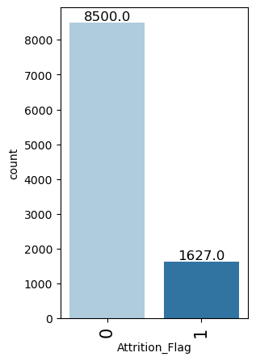

```python
# labeled_barplot
labeled_barplot(df, ATTRITION_FLAG)
```

### 2. Feature 'Customer_Age'

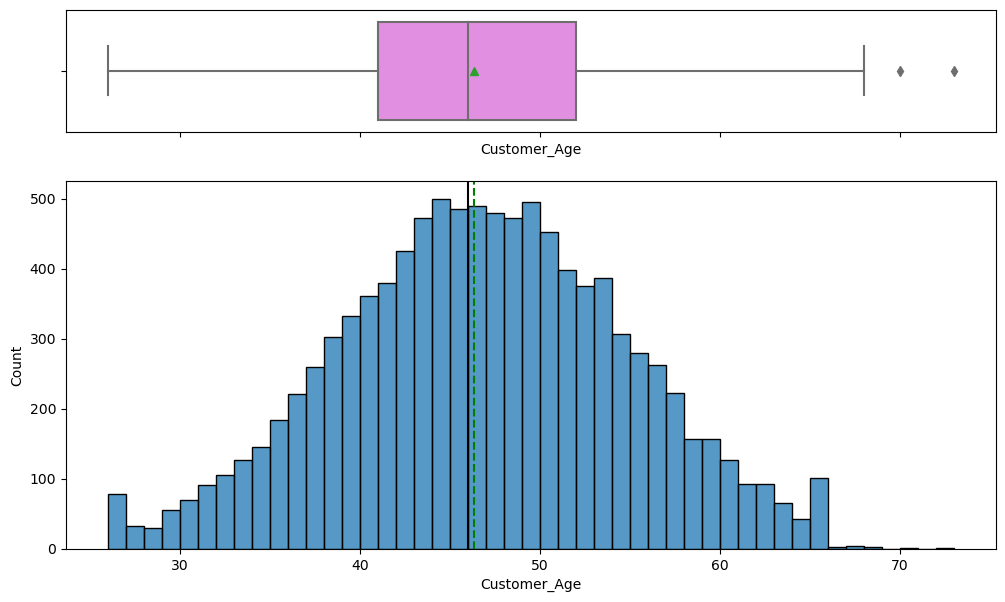

```python
# histogram boxplot
histogram_boxplot(df, CUSTOMER_AGE)
```

#### Observations

1. customer Age histogram is close to symmetric.
2. Box plot shows outliers.

### 3. Feature 'Gender'

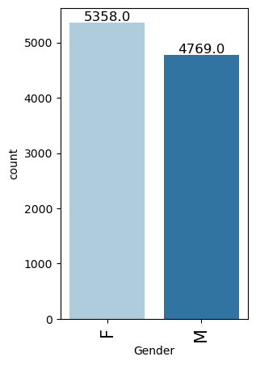

```python
# labeled barplot
labeled_barplot(df, GENDER)
```

#### Observations

1. Female count is more than Male count.
2. Female count is 5358 and Male count is 4769.

### 4. Feature 'Dependent_count'

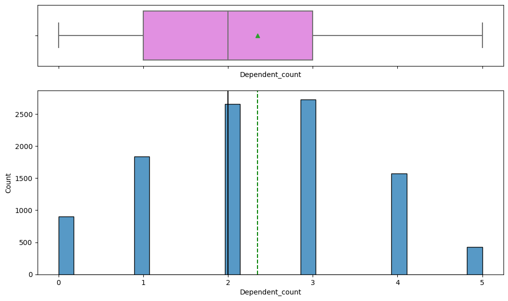

```python
# histogram boxplot
histogram_boxplot(df, DEPENDENT_COUNT)
```

#### Observations

1. Dependents with count 2 and 3 tops the list.
2. Dependents with count 5 has around 500 count.

### 5. Feature ‘Education_Level'

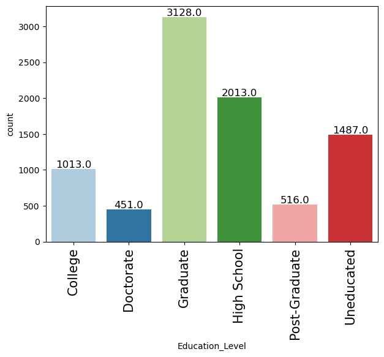

```python
# labeled barplot
labeled_barplot(df, EDUCATION_LEVEL)
```

#### Observations

1. Graduate customers tops the list.
2. Doctorate customers count is the least of all customers in education_level.

### 6. Feature 'Marital_Status'

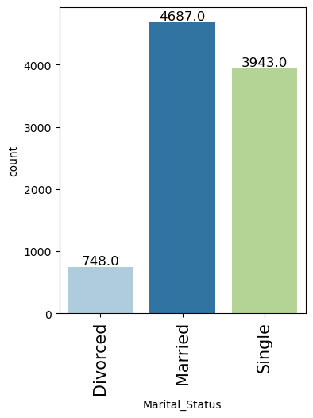

```python
# labeled barplot
labeled_barplot(df, MARITAL_STATUS)
```

#### Observations

1. Customers with "Marital_Status" tops the list.
2. Customers with "Divorced" status are 748.

### 7. Feature 'Income_Category'

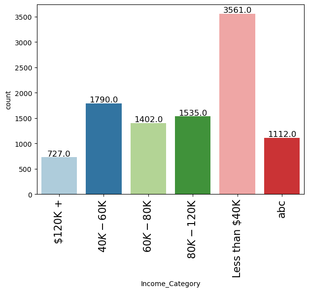

```python
# histogram boxplot
labeled_barplot(df, INCOME_CATEGORY)
```

#### Observations

1. Customers with income less than 40K USD tops the list.
2. Customers with income 120K USD and above are 727.

### 8. Feature 'Card_Category'

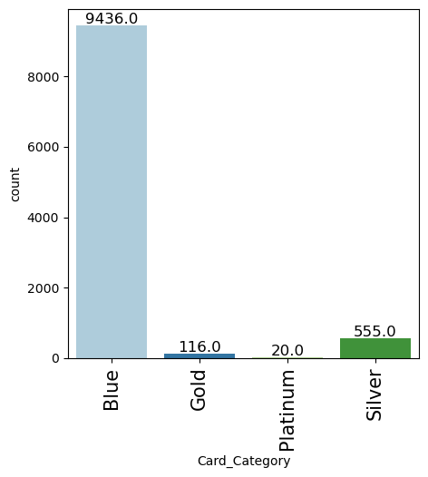

```python
# labeled_barplot
labeled_barplot(df, CARD_CATEGORY)
```

#### Observations

1. Customers with Blue card tops the list. Followed by Silver, Gold and Platinum.
2. Platinum card customers are just 20.

### 9. Feature 'Months_on_book'

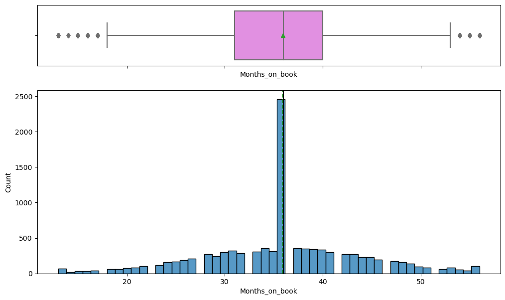

```python
# histogram boxplot
histogram_boxplot(df, MONTHS_ON_BOOK)
```

#### Observations

1. Months on Book shows outliers.
2. Months on Book below 20 and More than 50 is less.

### 10. Feature 'Total_Relationship_Count'

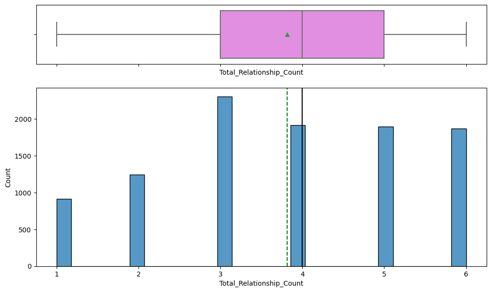

```python
# histogram boxplot
histogram_boxplot(df, TOTAL_RELATIONSHIP_COUNT)
```

#### Observations

1. Total relationship count 3 tops the list.
2. Total relationship count 1 is the least of all.

### 11. Feature 'Months_Inactive_12_mon'

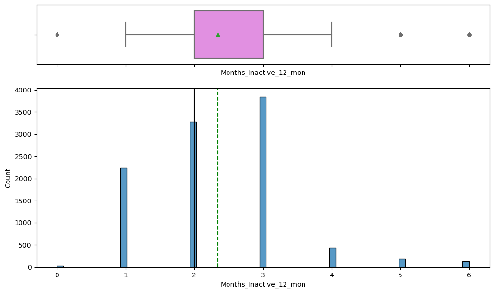

```python
# histogram boxplot
histogram_boxplot(df, MONTHS_INACTIVE_12_MON)
```

#### Observations

1. Boxplot shows outliers.
2. Months Inactive 12 mon with '3' tops the list.

### 12. Feature 'Contacts_Count_12_mon'

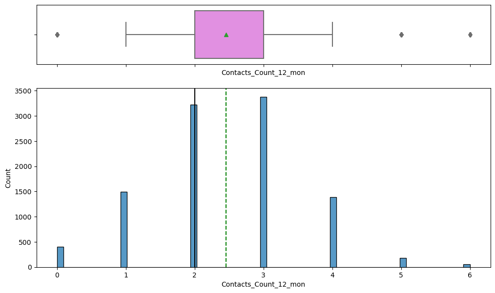

```python
# histogram boxplot
histogram_boxplot(df, CONTACTS_COUNT_12_MON)
```

#### Observations

1. Boxplot shows outliers.
2. Contacts Count 12 mon with '3' tops the list.

### 13. Feature 'Credit_Limit'

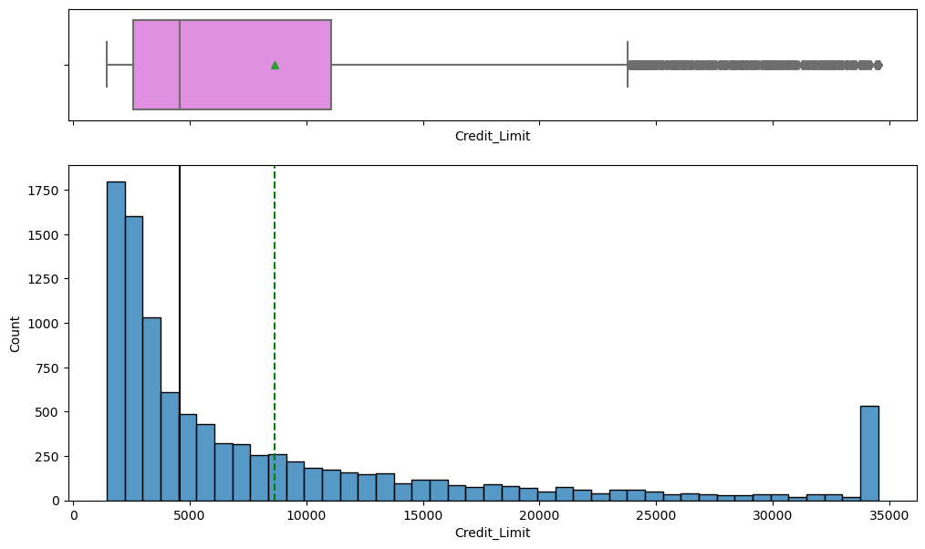

```python
# histogram boxplot
histogram_boxplot(df, CREDIT_LIMIT)
```

#### Observations

1. Credit Limit boxplot shows outliers.
2. Credit limit is kind of right skewed.

### 14. Feature 'Total_Revolving_Bal'

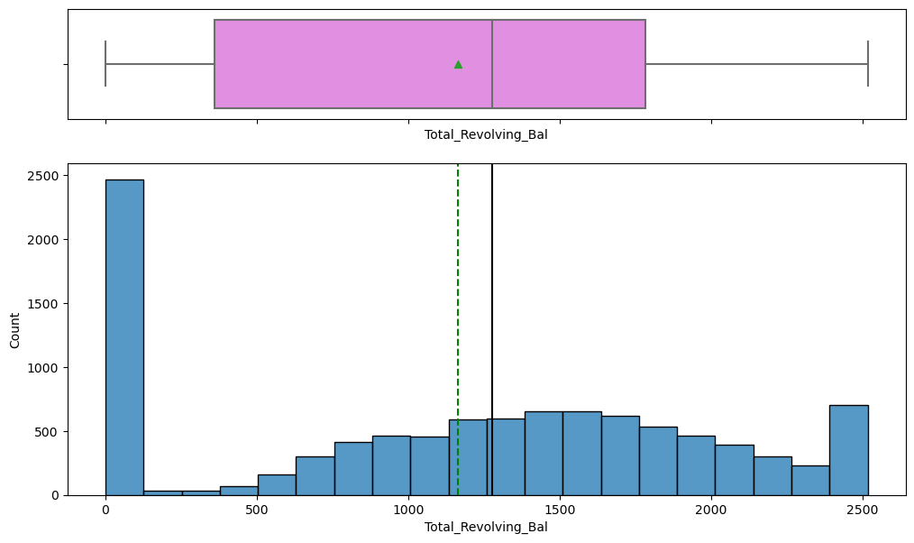

```python
# histogram boxplot
histogram_boxplot(df, TOTAL_REVOLVING_BAL)
```

#### Observations

1. Total revolving balance 0 and above tops the list.
2. Total revolving balance with 2500 and above is around 500+.

### 15. Feature 'Avg_Open_To_Buy'

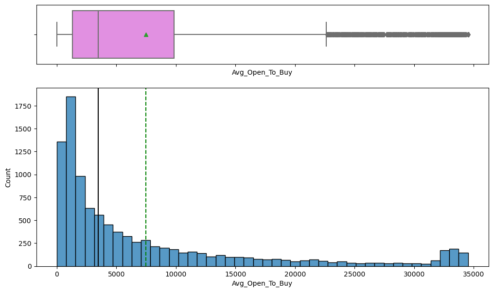

```python
# histogram boxplot
histogram_boxplot(df, AVG_OPEN_TO_BUY)
```

#### Observations

1. boxplot shows outliers.
2. avg_open_to_buy is right skewed.

### 16. Feature 'Total_Amt_Chng_Q4_Q1'

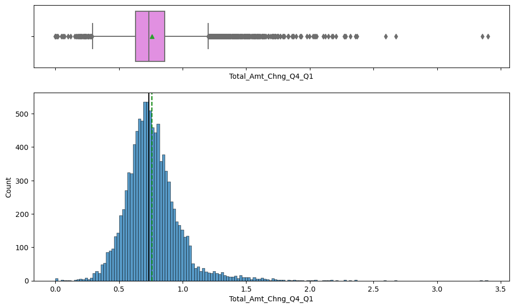

```python
# histogram boxplot
histogram_boxplot(df, TOTAL_AMT_CHNG_Q4_Q1)
```

#### Observations

1. Total_Amt_Chng_Q4_Q1 is symmetric
2. Boxplot shows the outliers.

### 17. Feature 'Total_Trans_Amt'

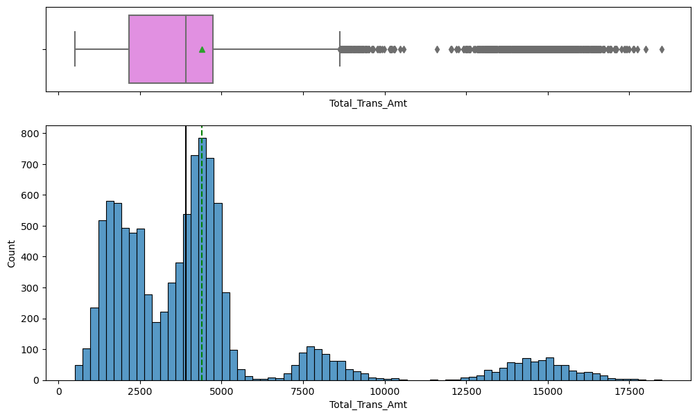

```python
# histogram boxplot
histogram_boxplot(df, TOTAL_TRANS_AMT)
```

#### Observations

1. Total_Trans_Amt boxplot shows outliers.
2. Total_Trans_Amt with 5000 tops the count list.

### 18. Feature 'Total_Trans_Ct'

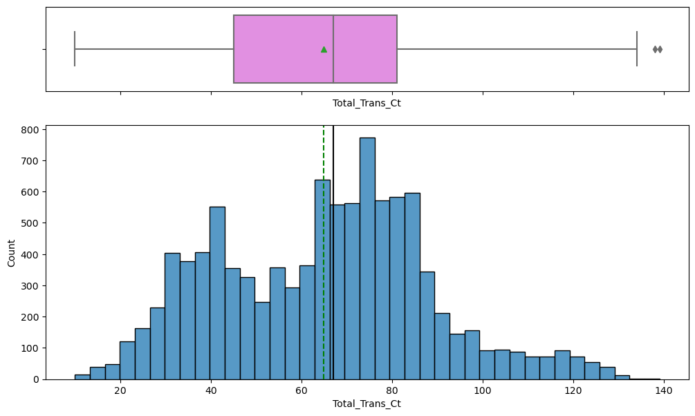

```python
# histogram boxplot
histogram_boxplot(df, TOTAL_TRANS_CT)
```

#### Observations

1. Total Trans Ct box plot shows few outliers.
2. Total Trans Ct average is around 65 to 70.

#### 19. Feature 'Total_Ct_Chng_Q4_Q1'

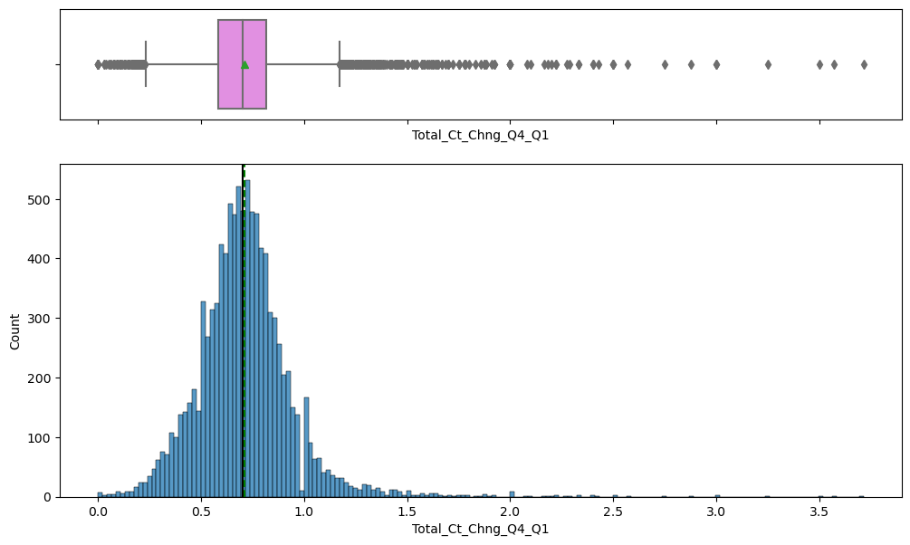

```python
# histogram boxplot
histogram_boxplot(df, TOTAL_CT_CHNG_Q4_Q1)
```

#### Observations

1. Total_Ct_Chng_Q4_Q1 boxplot shows outliers.
2. Total_Ct_Chng_Q4_Q1 is symmetric with outliers.

### 20. Feature 'Avg_Utilization_Ratio'

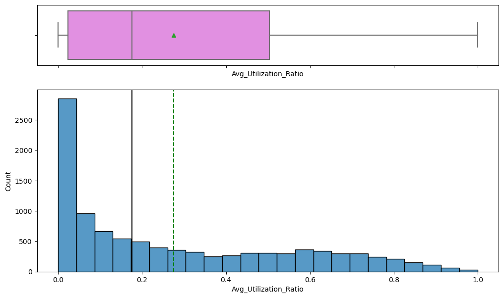

```python
# histogram boxplot
histogram_boxplot(df, AVG_UTILIZATION_RATIO)
```

#### Observations

1. Avg_Utilization_Ratio histogram is right skewed.

#### histograms

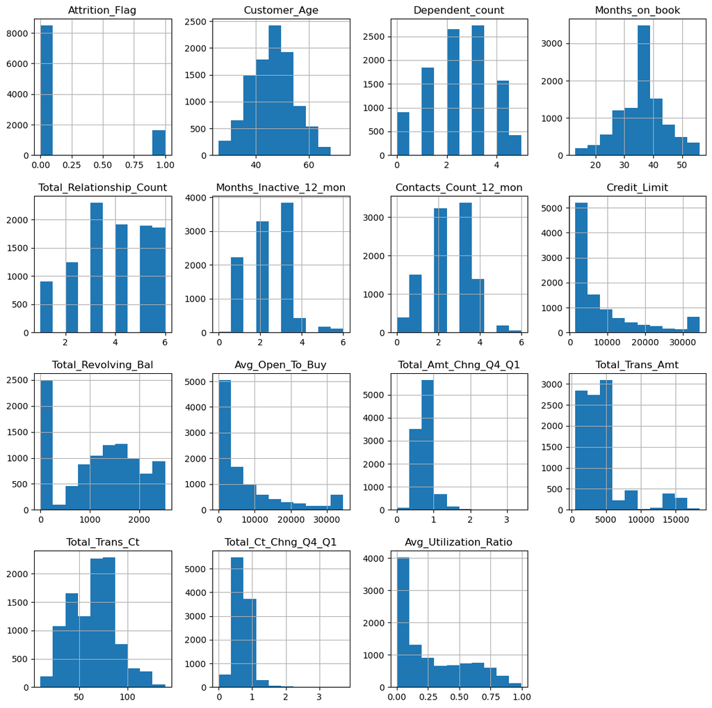

```python
# creating histograms
df.hist(figsize=(14, 14))
plt.show()
```

### 1. Correlation Check

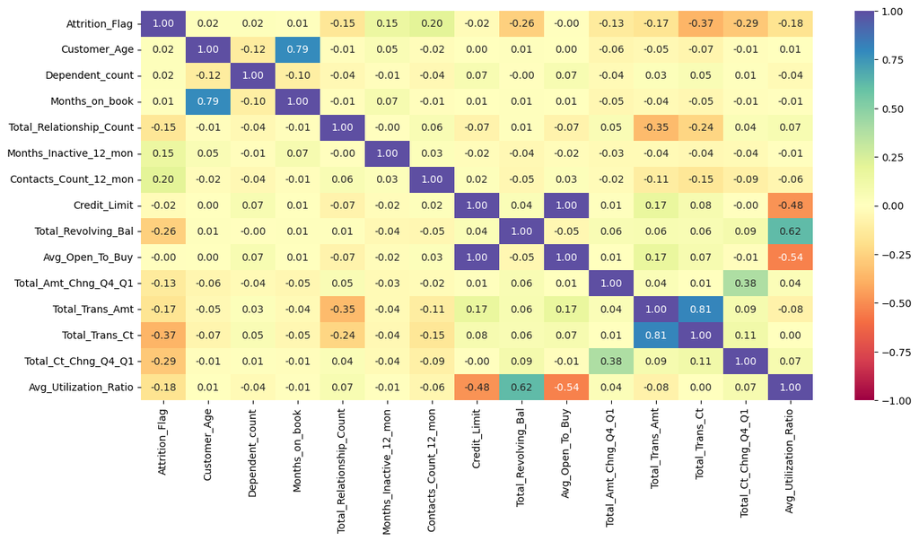

```python
# set the fig size
plt.figure(figsize=(15, 7))
# select only the numeric columns in the DataFrame
df_numeric = df.select_dtypes(include=np.number)
# heatmap
sns.heatmap(df_numeric.corr(), annot=True, vmin=-1, vmax=1, fmt=".2f", cmap='Spectral')
plt.show()
```

#### Observations

1. Credit_limit and Avg_open_to_buy is highly co-related.

### Attrition_Flag vs Gender

```
Attrition_Flag     0     1    All
Gender
All             8500  1627  10127
F               4428   930   5358
M               4072   697   4769
------------------------------------------------------------------------------------------------------------------------
```

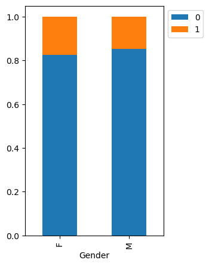

```python
# stacked_barplot Attrition_Flag vs Gender
stacked_barplot(df, GENDER, ATTRITION_FLAG)
```

#### Observations

1. Attrition flag for Male and Female are almost the same.
2. Female tops the list.

### Attrition_Flag vs Marital_Status

```
Attrition_Flag     0     1   All
Marital_Status
All             7880  1498  9378
Married         3978   709  4687
Single          3275   668  3943
Divorced         627   121   748
------------------------------------------------------------------------------------------------------------------------
```

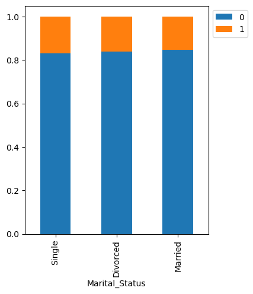

```python
# stacked_barplot Attrition_Flag vs Marital_Status
stacked_barplot(df, MARITAL_STATUS, ATTRITION_FLAG)
```

### Attrition_Flag vs Education_Level

```
Attrition_Flag      0     1   All
Education_Level
All              7237  1371  8608
Graduate         2641   487  3128
High School      1707   306  2013
Uneducated       1250   237  1487
College           859   154  1013
Doctorate         356    95   451
Post-Graduate     424    92   516
------------------------------------------------------------------------------------------------------------------------
```

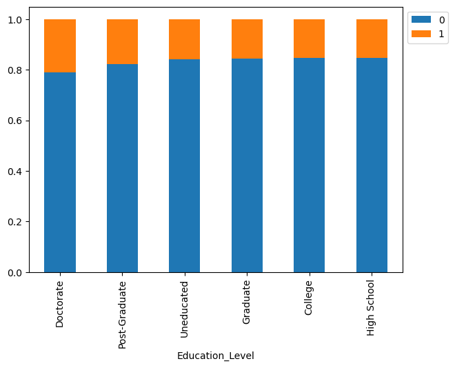

```python
# stacked_barplot Attrition_Flag vs Education_Level
stacked_barplot(df, EDUCATION_LEVEL, ATTRITION_FLAG)
```

### Attrition_Flag vs Income_Category

```
Attrition_Flag      0     1    All
Income_Category
All              8500  1627  10127
Less than $40K   2949   612   3561
$40K - $60K      1519   271   1790
$80K - $120K     1293   242   1535
$60K - $80K      1213   189   1402
abc               925   187   1112
$120K +           601   126    727
------------------------------------------------------------------------------------------------------------------------
```

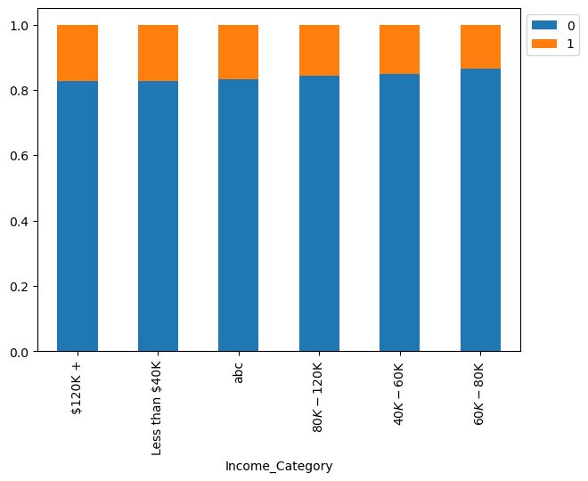

```python
# stacked_barplot Attrition_Flag vs Income_Category
stacked_barplot(df, INCOME_CATEGORY, ATTRITION_FLAG)
```

### Attrition_Flag vs Contacts_Count_12_mon

```
Attrition_Flag            0     1    All
Contacts_Count_12_mon
All                    8500  1627  10127
3                      2699   681   3380
2                      2824   403   3227
4                      1077   315   1392
1                      1391   108   1499
5                       117    59    176
6                         0    54     54
0                       392     7    399
------------------------------------------------------------------------------------------------------------------------
```

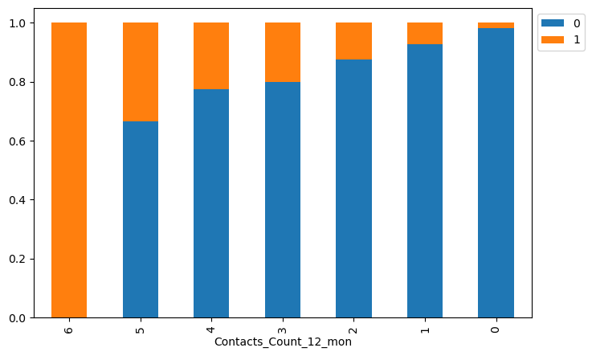

```python
# stacked_barplot Attrition_Flag vs Contacts_Count_12_mon
stacked_barplot(df, CONTACTS_COUNT_12_MON, ATTRITION_FLAG)
```

### Attrition_Flag vs Months_Inactive_12_mon

```
Attrition_Flag             0     1    All
Months_Inactive_12_mon
All                     8500  1627  10127
3                       3020   826   3846
2                       2777   505   3282
4                        305   130    435
1                       2133   100   2233
5                        146    32    178
6                        105    19    124
0                         14    15     29
------------------------------------------------------------------------------------------------------------------------
```

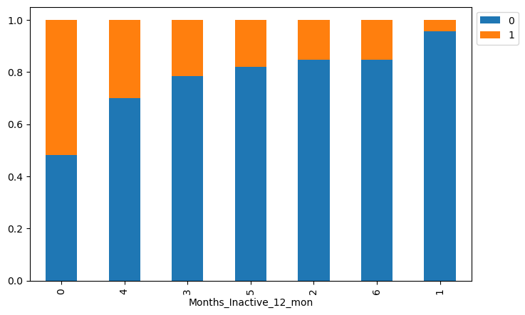

```python
# stacked_barplot Attrition_Flag vs Months_Inactive_12_mon
stacked_barplot(df, MONTHS_INACTIVE_12_MON, ATTRITION_FLAG)
```

### Attrition_Flag vs Total_Relationship_Count

```
Attrition_Flag               0     1    All
Total_Relationship_Count
All                       8500  1627  10127
3                         1905   400   2305
2                          897   346   1243
1                          677   233    910
5                         1664   227   1891
4                         1687   225   1912
6                         1670   196   1866
------------------------------------------------------------------------------------------------------------------------
```

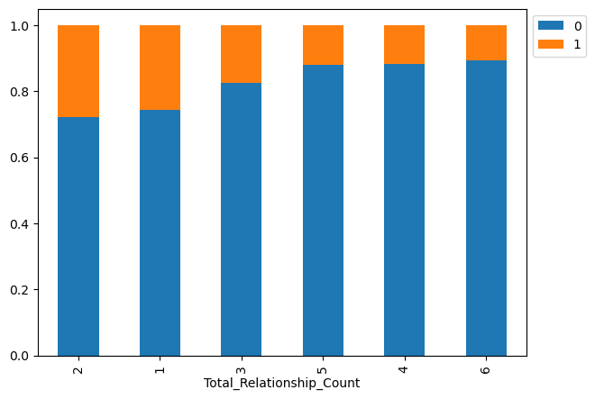

```python
# stacked_barplot Attrition_Flag vs Total_Relationship_Count
stacked_barplot(df, TOTAL_RELATIONSHIP_COUNT, ATTRITION_FLAG)
```

### Attrition_Flag vs Dependent_count

```
Attrition_Flag      0     1    All
Dependent_count
All              8500  1627  10127
3                2250   482   2732
2                2238   417   2655
1                1569   269   1838
4                1314   260   1574
0                 769   135    904
5                 360    64    424
------------------------------------------------------------------------------------------------------------------------
```

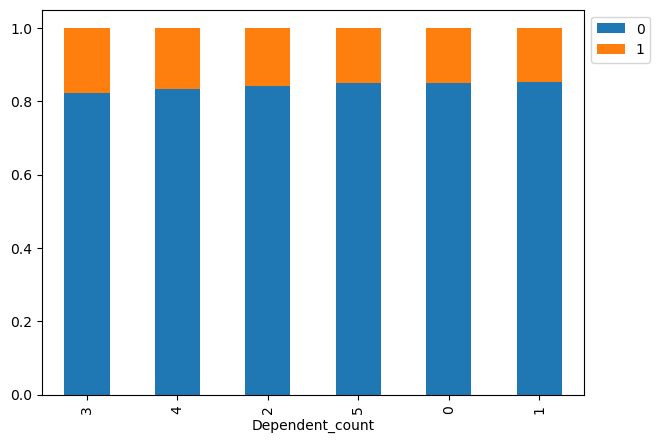

```python
# stacked_barplot Attrition_Flag vs Dependent_count
stacked_barplot(df, DEPENDENT_COUNT, ATTRITION_FLAG)
```

### Attrition_Flag vs Total_Revolving_Bal

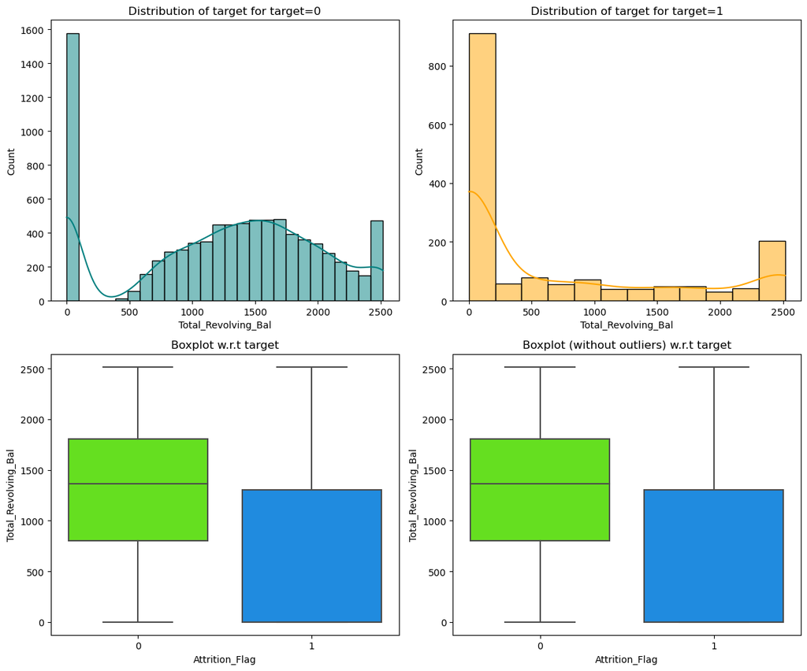

```python
# distribution_plot_wrt_target Attrition_Flag vs Total_Revolving_Bal
distribution_plot_wrt_target(df, TOTAL_REVOLVING_BAL, ATTRITION_FLAG)
```